# compgen2021: Week 1 exercises

O. Daniel López Olmos

# Exercises for Week1

## Statistics for genomics

### How to summarize collection of data points: The idea behind statistical distributions

1. Calculate the means and variances of the rows of the following simulated data set, and plot the distributions of means and variances using `hist()` and `boxplot()` functions. [Difficulty: **Beginner/Intermediate**]

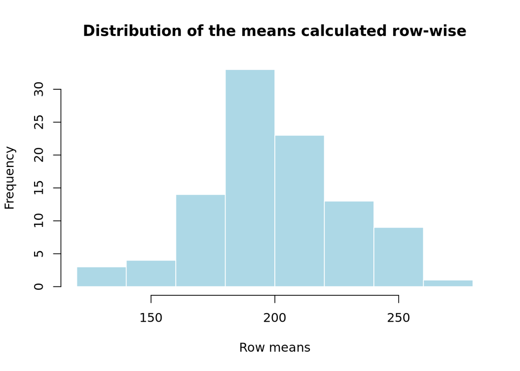

```r
#import libraries
library(mosaic, warn.conflicts = F)
set.seed(100)

#sample data matrix from normal distribution
gset=rnorm(600,mean=200,sd=70)
data=matrix(gset,ncol=6)

#calculate means and variances
rowMeans <- apply(data, 1, mean)
rowVars <- apply(data, 1, var)

#plot the distributions
hist(rowMeans, col = "lightblue", border = "white",
     main = "Distribution of the means calculated row-wise",
     xlab = "Row means")
```

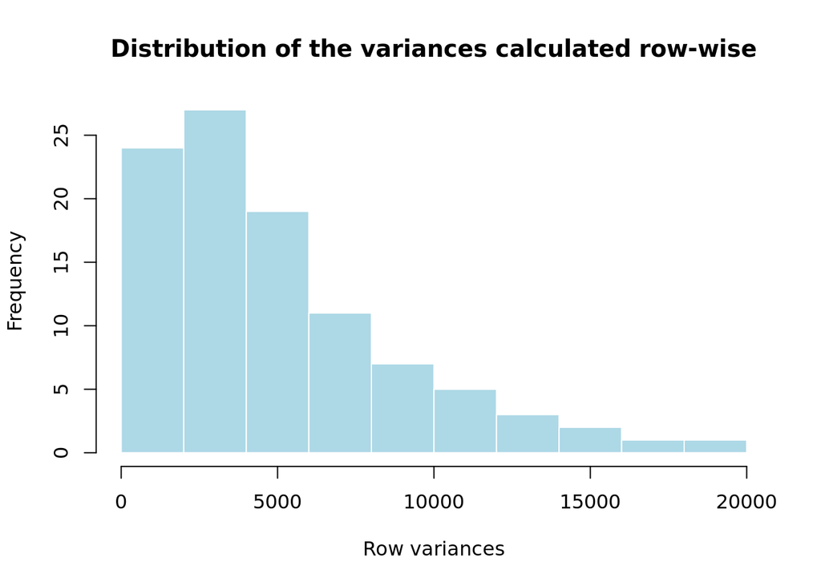

```r
hist(rowVars, col = "lightblue", border = "white",
     main = "Distribution of the variances calculated row-wise",
     xlab = "Row variances")
```

2. Using the data generated above, calculate the standard deviation of the distribution of the means using the `sd()` function. Compare that to the expected standard error obtained from the central limit theorem keeping in mind the population parameters were $\sigma=70$ and $n=6$. How does the estimate from the random samples change if we simulate more data with `data=matrix(rnorm(6000,mean=200,sd=70),ncol=6)`? [Difficulty: **Beginner/Intermediate**]
3. Simulate 30 random variables using the `rpois()` function. Do this 1000 times and calculate the mean of each sample. Plot the sampling distributions of the means using a histogram. Get the 2.5th and 97.5th percentiles of the distribution. [Difficulty: **Beginner/Intermediate**]

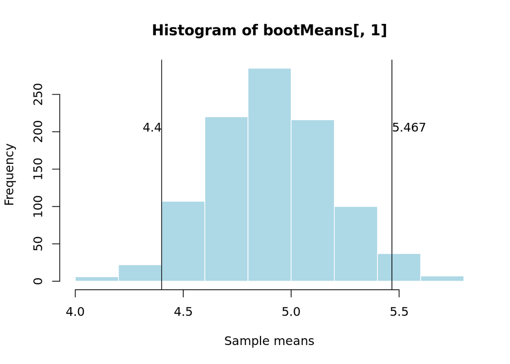

```r
require(mosaic, quietly = T)
#HINT
set.seed(100)

#sample 30 values from poisson dist with lambda paramater = 30
pois1 <- rpois(30, lambda=5)
#bootstrap resampling
bootMeans = mosaic::do(1000) * mean(resample(pois1))
#get percentiles from the bootstrap means
q = quantile(bootMeans[, 1], p = c(0.025, 0.975))

#plot sampling distributions
hist(bootMeans[,1], col = "lightblue", border = "white",
                    xlab = "Sample means")
abline(v = c(q[1], q[2] ), col = "black")
text(x = q[1], y = 200, round(q[1], 3), adj = c(1, 0))
text(x = q[2], y = 200, round(q[2], 3), adj = c(0, 0))
```

4. Use the `t.test()` function to calculate confidence intervals of the mean on the first random sample `pois1` simulated from the `rpois()` function below. [Difficulty: **Intermediate**]

```r
#calculate confidence intervals with 't.test()'
t.test(pois1)
```

```
##
##  One Sample t-test
##
## data:  pois1
## t = 17.663, df = 29, p-value < 2.2e-16
## alternative hypothesis: true mean is not equal to 0
## 95 percent confidence interval:
##  4.362104 5.504563
## sample estimates:
## mean of x
##  4.933333
```

Confidence intervals: [4.362104, 5.504563]

5. Use the bootstrap confidence interval for the mean on `pois1`. [Difficulty: **Intermediate/Advanced**]

### How to test for differences in samples

1. Test the difference of means of the following simulated genes using the randomization, `t-test()`, and `wilcox.test()` functions. Plot the distributions using histograms and boxplots. [Difficulty: **Intermediate/Advanced**]

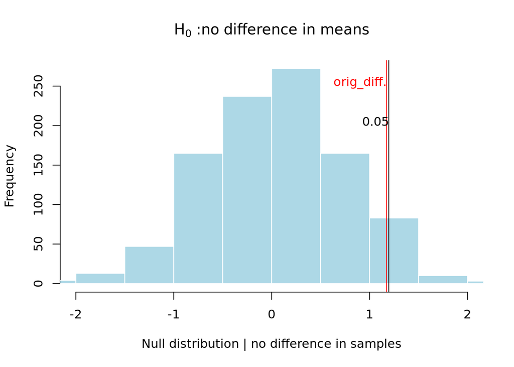

```r
set.seed(101)
gene1 <- rnorm(30, mean = 4, sd = 3)
gene2 <- rnorm(30, mean = 3, sd = 3)
#calculate original difference
orig_diff <- mean(gene1) - mean(gene2)


#create a df for our data
genesDF <- data.frame(exp = c(gene1, gene2), group = c(rep("group1", 30), rep("group2", 30)))
#null distribution-no difference in means
exp_null <- do(1000) * diff(mosaic::mean(exp ~ shuffle(group), data = genesDF))

#test for differences using randomization
hist(exp_null[, 1], xlab = "Null distribution | no difference in samples",
     main = expression(paste(H[0]," :no difference in means") ),
     xlim = c(-2,2), col = "lightblue", border = "white")
abline(v = quantile(exp_null[, 1], 0.95), col = "black")
abline(v = orig_diff, col = "red" )
text(x = quantile(exp_null[, 1], 0.95), y = 200, "0.05", adj = c(1, 0), col = "black")
text(x = orig_diff, y = 250, "orig_diff.", adj = c(1, 0), col = "red")
```

Test the difference of means of the simulated genes using `t-test()`.

```r
#test differences of means using 't.test()'
stats::t.test(gene1, gene2)
```

```
##
##  Welch Two Sample t-test
##
## data:  gene1 and gene2
## t = 1.6188, df = 55.719, p-value = 0.1111
## alternative hypothesis: true difference in means is not equal to 0
## 95 percent confidence interval:
##  -0.2787179  2.6248604
## sample estimates:
## mean of x mean of y
##  3.751368  2.578297
```

Test the difference of means of the simulated genes using `wilcox.test()`.

```r
wilcox.test(gene1, gene2, conf.int = T)
```

```
##
##  Wilcoxon rank sum exact test
##
## data:  gene1 and gene2
## W = 530, p-value = 0.2418
## alternative hypothesis: true location shift is not equal to 0
## 95 percent confidence interval:
##  -0.4742521  2.5133503
## sample estimates:
## difference in location
##               1.049103
```

Plot the distributions using histograms and boxplots.

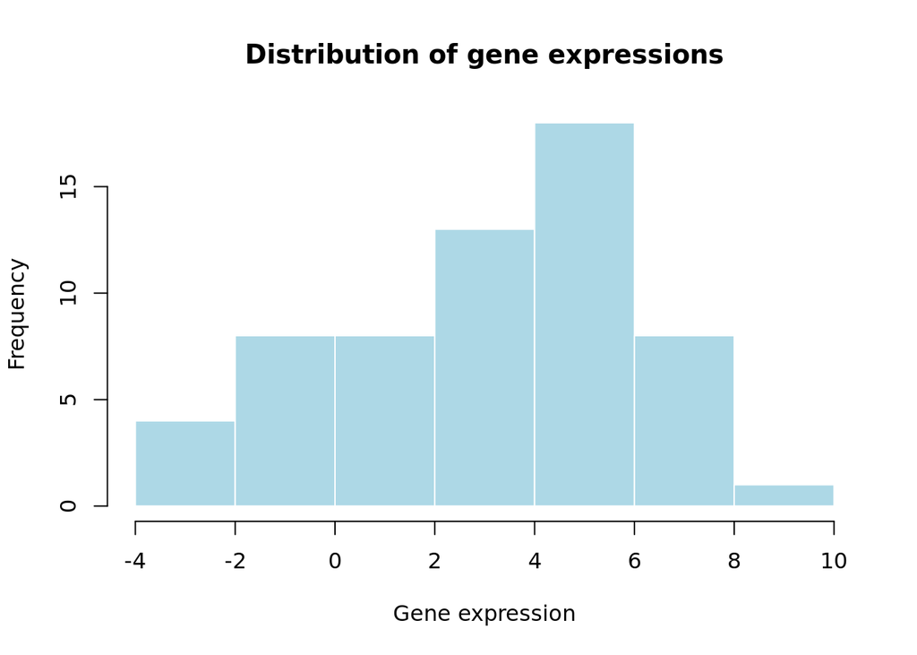

```r
#plot the distributions of gene expressions
hist(genesDF[, 1], #histogram
     main = "Distribution of gene expressions",
     xlab = "Gene expression",
     col = "lightblue", border = "white")
```

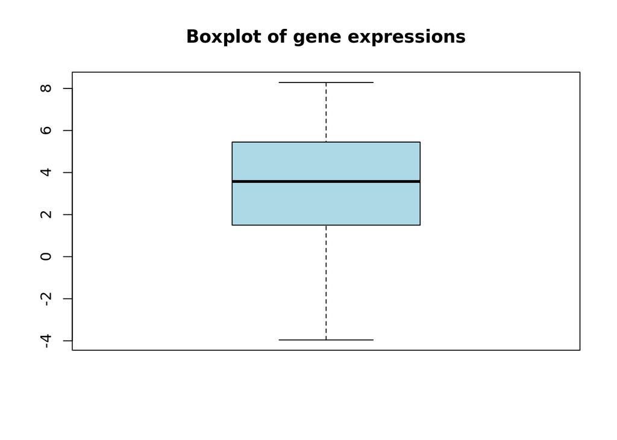

```r
#boxplot
boxplot(genesDF[,1],
     main = "Boxplot of gene expressions",
     col = "lightblue", border = "black")
```

2. Test the difference of the means of the following simulated genes using the randomization, `t-test()` and `wilcox.test()` functions. Plot the distributions using histograms and boxplots. [Difficulty: **Intermediate/Advanced**]

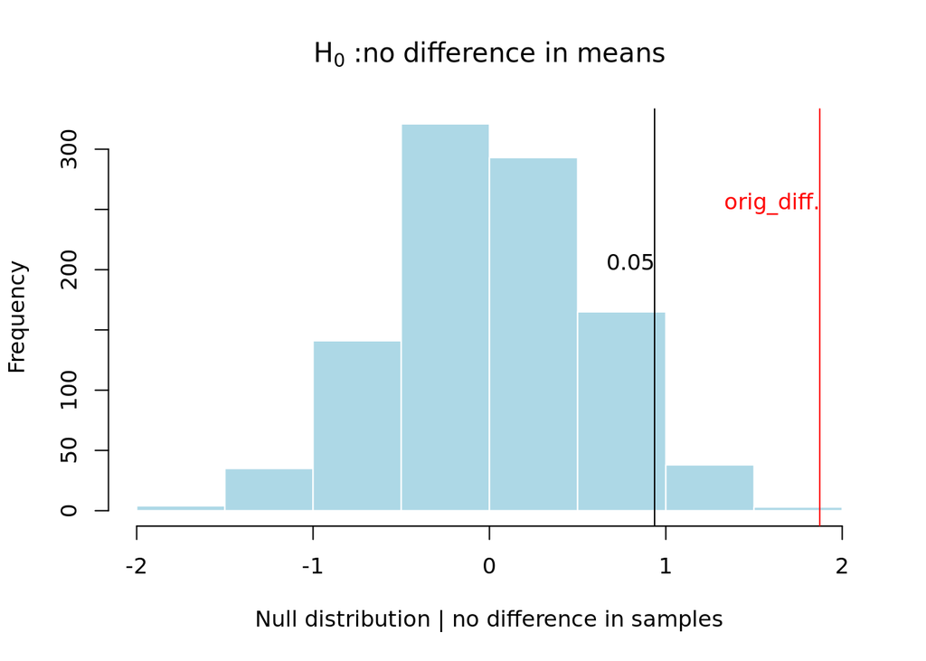

```r
set.seed(100)
gene1 = rnorm(30, mean = 4, sd = 2)
gene2 = rnorm(30, mean = 2, sd = 2)
#calculate original difference
orig_diff = mean(gene1) - mean(gene2)


#create a df for our data
genesDF = data.frame(exp = c(gene1, gene2), group = c(rep("group1", 30), rep("group2", 30)))
#null distribution-no difference in means
exp_null <- do(1000) * diff(mosaic::mean(exp ~ shuffle(group), data = genesDF))

#test for differences using randomization
hist(exp_null[, 1], xlab = "Null distribution | no difference in samples",
     main = expression(paste(H[0]," :no difference in means") ),
     xlim = c(-2,2), col = "lightblue", border = "white")
abline(v = quantile(exp_null[, 1], 0.95), col = "black")
abline(v = orig_diff, col = "red" )
text(x = quantile(exp_null[, 1], 0.95), y = 200, "0.05", adj = c(1, 0), col = "black")
text(x = orig_diff, y = 250, "orig_diff.", adj = c(1, 0), col = "red")
```

Test the difference of means of the simulated genes using `t-test()`.

```r
#test differences of means using 't.test()'
stats::t.test(gene1, gene2)
```

```
##
##  Welch Two Sample t-test
##
## data:  gene1 and gene2
## t = 3.7653, df = 47.552, p-value = 0.0004575
## alternative hypothesis: true difference in means is not equal to 0
## 95 percent confidence interval:
##  0.872397 2.872761
## sample estimates:
## mean of x mean of y
##  4.057728  2.185149
```

Test the difference of means of the simulated genes using `wilcox.test()`.

```r
wilcox.test(gene1, gene2, conf.int = T)
```

```
##
##  Wilcoxon rank sum exact test
##
## data:  gene1 and gene2
## W = 658, p-value = 0.001795
## alternative hypothesis: true location shift is not equal to 0
## 95 percent confidence interval:
##  0.6956318 2.7997818
## sample estimates:
## difference in location
##               1.740907
```

Plot the distributions using histograms and boxplots.

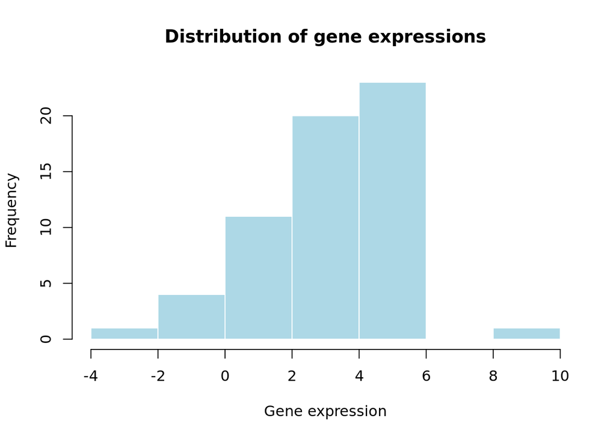

```r
#plot the distributions of gene expressions
hist(genesDF[, 1], #histogram
     main = "Distribution of gene expressions",
     xlab = "Gene expression",
     col = "lightblue", border = "white")
```

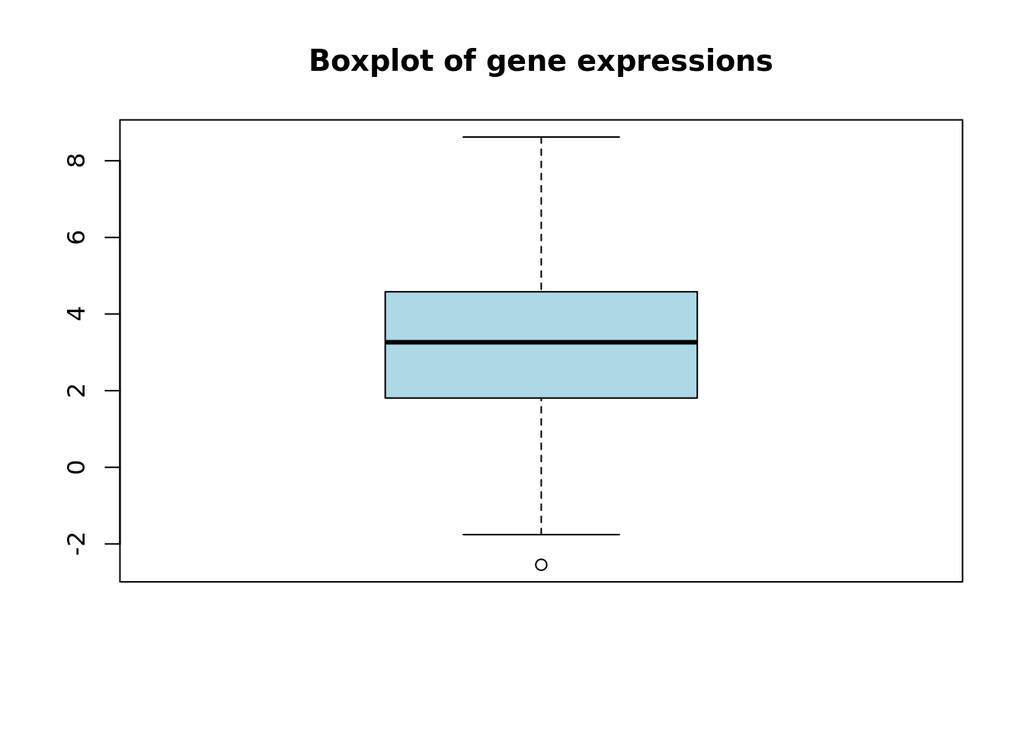

```r
#boxplot
boxplot(genesDF[,1],
     main = "Boxplot of gene expressions",
     col = "lightblue", border = "black")
```

3. We need an extra data set for this exercise. Read the gene expression data set as follows: `gexpFile=system.file("extdata","geneExpMat.rds",package="compGenomRData") data=readRDS(gexpFile)`. The data has 100 differentially expressed genes. The first 3 columns are the test samples, and the last 3 are the control samples. Do a t-test for each gene (each row is a gene), and record the p-values. Then, do a moderated t-test, as shown in section “Moderated t-tests” in this chapter, and record the p-values. Make a p-value histogram and compare two approaches in terms of the number of significant tests with the $0.05$ threshold. On the p-values use FDR (BH), Bonferroni and q-value adjustment methods. Calculate how many adjusted p-values are below 0.05 for each approach. [Difficulty: **Intermediate/Advanced**]

```r
require(matrixStats, quietly = T)
```

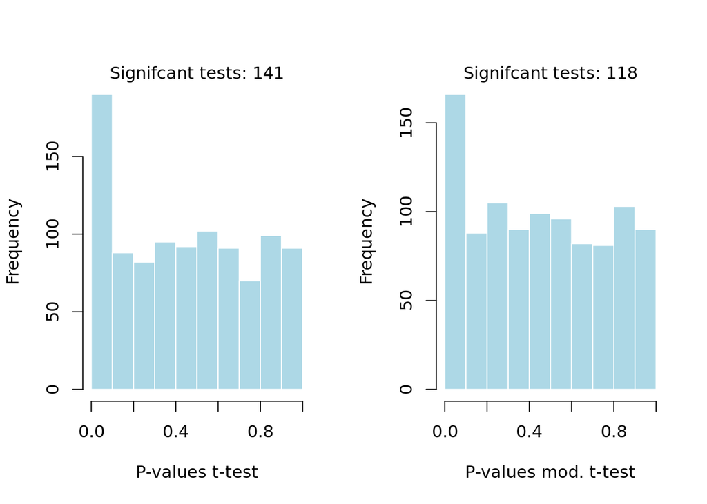

```r
#import data
gexpFile = system.file("extdata", "geneExpMat.rds", package = "compGenomRData")
data = readRDS(gexpFile)

#true difference in means
dx = rowMeans(data[, 1:3]) - rowMeans(data[, 4:6])

n1 = 3
n2 = 3
#get the esimate of pooled variance
stderr = sqrt((rowVars(data[, 1:3])*(n1-1) + rowVars(data[, 4:6])*(n2-1)) / (n1+n2-2) * ( 1/n1 + 1/n2 ))
#do the shrinking towards median
mod.stderr = (stderr + median(stderr)) / 2 # moderation in variation

#do a t-test for each gene and record p-values
t = dx / stderr
p = 2*pt( -abs(t), n1+n2-2 )

#do a moderated t-test and record p-values
t.mod <- dx / mod.stderr
p.mod = 2*pt( -abs(t.mod), n1+n2-2 )

#make a p-value histogram and compare both approaches
par(mfrow = c(1, 2))

hist(p, col = "lightblue", border = "white", main = "",
     xlab = "P-values t-test")
mtext(paste("Signifcant tests:", sum(p < 0.05))  )

hist(p.mod, col = "lightblue", border="white", main="",
     xlab="P-values mod. t-test")
mtext(paste("Signifcant tests:", sum(p.mod <0.05)))
```

On the p-values use FDR (BH), Bonferroni and q-value adjustment methods. Calculate how many adjusted p-values are below 0.05 for each approach.

```r
require(qvalue, quietly = T)

#FDR adjusted value
fdr.adj.pval = p.adjust(p, method = "fdr")
#Bonferroni correction
bonf.pval=p.adjust(p, method = "bonferroni")
#q-value
qvalues <- qvalue(p)$q

n_pvalues <- data.frame(fdr_adj_pval = c(sum(fdr.adj.pval < 0.05)),
                        bonf_pval = sum(bonf.pval < 0.05),
                        q_values = sum(qvalues < 0.05))
rownames(n_pvalues) <- "# of p-values below 0.05"
n_pvalues
```

|  | fdr_adj_pval | bonf_pval | q_values |
| --- | --- | --- | --- |
| # of p-values below 0.05 | 99 | 25 | 100 |

### Relationship between variables: Linear models and correlation

Below we are going to simulate X and Y values that are needed for the rest of the exercise.

```r
# set random number seed, so that the random numbers from the text
# is the same when you run the code.
set.seed(32)

# get 50 X values between 1 and 100
x = runif(50, 1, 100)

# set b0,b1 and variance (sigma)
b0 = 10
b1 = 2
sigma = 20
# simulate error terms from normal distribution
eps = rnorm(50, 0, sigma)
# get y values from the linear equation and addition of error terms
y = b0 + b1*x+ eps
```

1. Run the code then fit a line to predict Y based on X. [Difficulty:**Intermediate**]

```r
#instance the model
model <- lm(y ~ x)
```

2. Plot the scatter plot and the fitted line. [Difficulty:**Intermediate**]

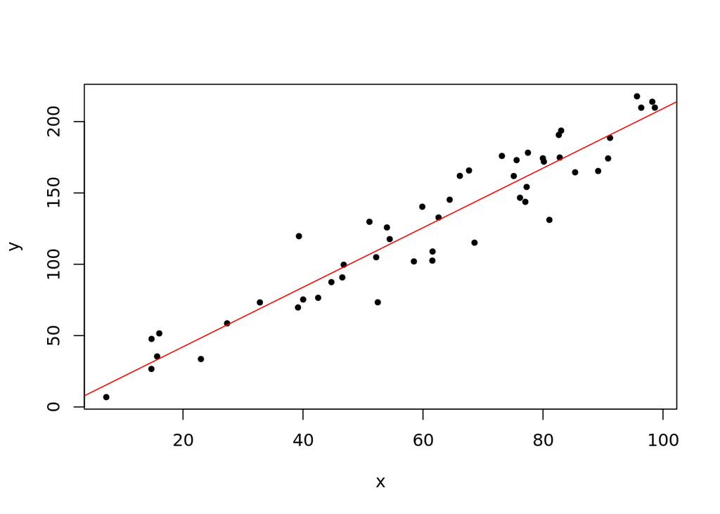

```r
#scatter plot
plot(x, y, pch=20)
#plot the fitted line
abline(model, col = "red")
```

3. Calculate correlation and R^2. [Difficulty:**Intermediate**]

```r
cat("Correlation of model: ", correlation <- cor(x, y), "\n")
```

```
## Correlation of model:  0.9511939
```

```r
R2 <-summary.lm(model)$r.squared
cat("R squared of model: ", R2)
```

```
## R squared of model:  0.9047699
```

Correlation shows a high value of correlation between both variables. The R^2 is sufficiently good to assume that the ‘x’ variable has the power to predict ‘y’ values.

4. Run the `summary()` function and try to extract P-values for the model from the object returned by `summary`. See `?summary.lm`. [Difficulty:**Intermediate/Advanced**]

```r
#p-value: < 2.2e-16
sum <- summary.lm(model)
sum
```

```
##
## Call:
## lm(formula = y ~ x)
##
## Residuals:
##    Min     1Q Median     3Q    Max
## -38.50 -12.62   1.66  14.26  37.20
##
## Coefficients:
##             Estimate Std. Error t value Pr(>|t|)
## (Intercept)  0.40951    6.43208   0.064     0.95
## x            2.08742    0.09775  21.355   <2e-16 ***
## ---
## Signif. codes:  0 '***' 0.001 '**' 0.01 '*' 0.05 '.' 0.1 ' ' 1
##
## Residual standard error: 16.96 on 48 degrees of freedom
## Multiple R-squared:  0.9048, Adjusted R-squared:  0.9028
## F-statistic:   456 on 1 and 48 DF,  p-value: < 2.2e-16
```

5. Plot the residuals vs. the fitted values plot, by calling the `plot()` function with `which=1` as the second argument. First argument is the model returned by `lm()`. [Difficulty:**Advanced**]

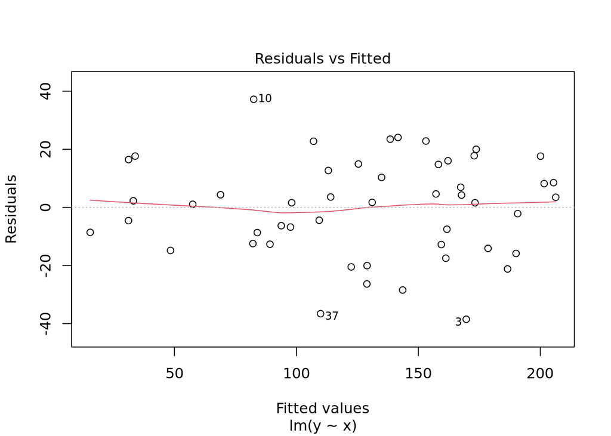

```r
plot(model, which = 1)
```

The plot above shows no obvious pattern between our residuals and fitted values, showing no tendecy in our model.

6. For the next exercises, read the data set histone modification data set. Use the following to get the path to the file:

```r
#import data
hmodFile=system.file("extdata",
                    "HistoneModeVSgeneExp.rds",
                     package="compGenomRData")
data2 <- readRDS(hmodFile)
```

There are 3 columns in the dataset. These are measured levels of H3K4me3, H3K27me3 and gene expression per gene. Once you read in the data, plot the scatter plot for H3K4me3 vs. expression. [Difficulty:**Beginner**]

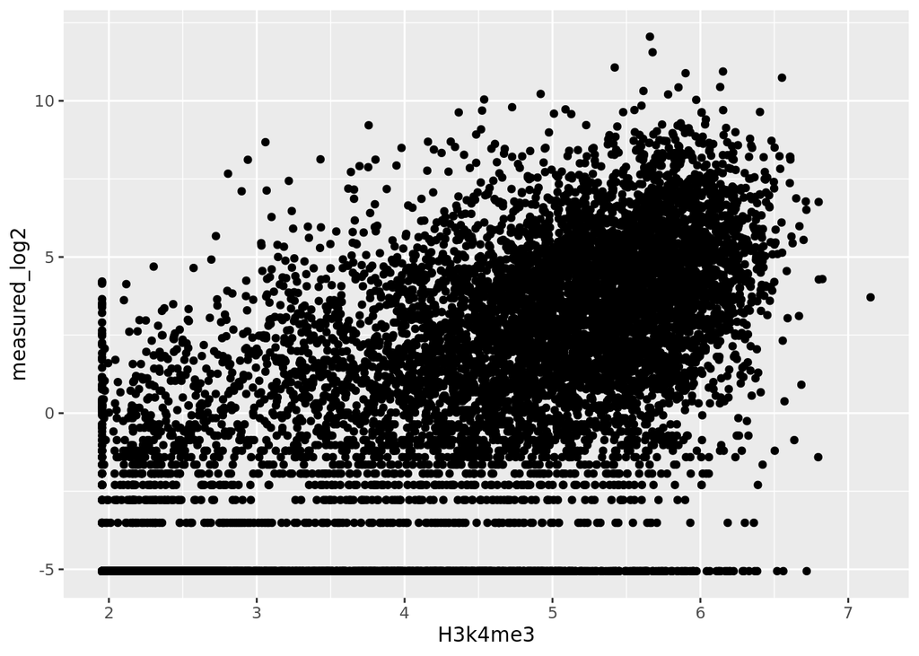

```r
library(ggplot2)

#plot H3K4me3 vs. expression.
ggplot(data2, aes(x = H3k4me3, y = measured_log2)) +
  geom_point()
```

7. Plot the scatter plot for H3K27me3 vs. expression. [Difficulty:**Beginner**]

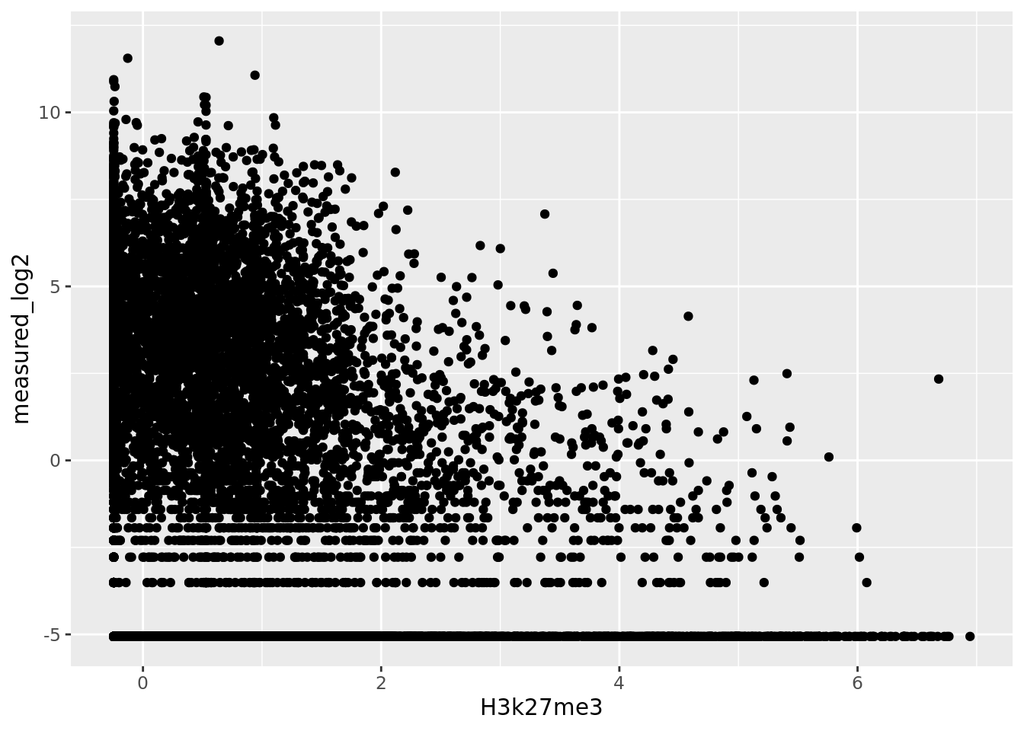

```r
#plot H3K27me3 vs. expression
ggplot(data2, aes(x = H3k27me3, y = measured_log2)) +
  geom_point()
```

8. Fit the model for prediction of expression data using: 1) Only H3K4me3 as explanatory variable, 2) Only H3K27me3 as explanatory variable, and 3) Using both H3K4me3 and H3K27me3 as explanatory variables. Inspect the `summary()` function output in each case, which terms are significant. [Difficulty:**Beginner/Intermediate**]

```r
#fitting a regression model using H3K4me3 as explanatory variable
model2 <- lm(measured_log2 ~ H3k4me3, data = data2)
summary(model2)
```

```
##
## Call:
## lm(formula = measured_log2 ~ H3k4me3, data = data2)
##
## Residuals:
##      Min       1Q   Median       3Q      Max
## -11.0503  -1.0218  -0.1054   1.2508  11.2229
##
## Coefficients:
##             Estimate Std. Error t value Pr(>|t|)
## (Intercept) -9.68153    0.05853  -165.4   <2e-16 ***
## H3k4me3      2.33263    0.01457   160.1   <2e-16 ***
## ---
## Signif. codes:  0 '***' 0.001 '**' 0.01 '*' 0.05 '.' 0.1 ' ' 1
##
## Residual standard error: 2.565 on 13729 degrees of freedom
## Multiple R-squared:  0.6511, Adjusted R-squared:  0.6511
## F-statistic: 2.563e+04 on 1 and 13729 DF,  p-value: < 2.2e-16
```

From the above output, the first thing to notice is the p-value of the model, which is close to 0, meaning that we can trust the model. As so, p-values for the explanatory variable ‘H3K4me3’ and for the intercept are really trustworthy.

```r
#fitting a regression model using H3K27me3 as explanatory variable
model3 <- lm(measured_log2 ~ H3k27me3, data = data2)
summary(model3)
```

```
##
## Call:
## lm(formula = measured_log2 ~ H3k27me3, data = data2)
##
## Residuals:
##     Min      1Q  Median      3Q     Max
## -4.8885 -4.0716 -0.5573  3.8014 12.9216
##
## Coefficients:
##             Estimate Std. Error t value Pr(>|t|)
## (Intercept) -0.36390    0.04394  -8.282   <2e-16 ***
## H3k27me3    -0.78807    0.03117 -25.283   <2e-16 ***
## ---
## Signif. codes:  0 '***' 0.001 '**' 0.01 '*' 0.05 '.' 0.1 ' ' 1
##
## Residual standard error: 4.245 on 13729 degrees of freedom
## Multiple R-squared:  0.04449,    Adjusted R-squared:  0.04442
## F-statistic: 639.2 on 1 and 13729 DF,  p-value: < 2.2e-16
```

```r
#fitting a regression model using both epigenetic marks as explanatory variables
model4 <- lm(measured_log2 ~ H3k4me3 + H3k27me3, data = data2)
summary(model4)
```

```
##
## Call:
## lm(formula = measured_log2 ~ H3k4me3 + H3k27me3, data = data2)
##
## Residuals:
##      Min       1Q   Median       3Q      Max
## -11.0564  -1.0702  -0.3066   1.2486  10.8950
##
## Coefficients:
##             Estimate Std. Error t value Pr(>|t|)
## (Intercept) -9.11803    0.05980 -152.48   <2e-16 ***
## H3k4me3      2.29815    0.01417  162.17   <2e-16 ***
## H3k27me3    -0.54532    0.01832  -29.77   <2e-16 ***
## ---
## Signif. codes:  0 '***' 0.001 '**' 0.01 '*' 0.05 '.' 0.1 ' ' 1
##
## Residual standard error: 2.486 on 13728 degrees of freedom
## Multiple R-squared:  0.6723, Adjusted R-squared:  0.6723
## F-statistic: 1.408e+04 on 2 and 13728 DF,  p-value: < 2.2e-16
```

Our multivariate model shows to be a better model that the models using a single explanatory variable, with a R-squared score = 0.6723. Which suggests that predicting gene expression is better when both epigenetic marks are used in modeling.

10. Is using H3K4me3 and H3K27me3 better than the model with only H3K4me3? [Difficulty:**Intermediate**]

```r
singlemodelCorr <- summary.lm(model2)$r.squared
multimodelCorr <- summary.lm(model4)$r.squared

cat("Correlation of model with only H3K4me3 as explanatory variable: ", singlemodelCorr, "\n")
```

```
## Correlation of model with only H3K4me3 as explanatory variable:  0.6511409
```

```r
cat("Correlation of model with H3K4me3 and H3K27me3 as explanatory variables: ", multimodelCorr)
```

```
## Correlation of model with H3K4me3 and H3K27me3 as explanatory variables:  0.6722997
```